# Report with results from the ‘Annotate and Expand Omics Data Matrix’ script (v.1)

Ferran Brianso

10 septiembre 2021

Targets’ report corresponding to the functions that annotate any original expression matrix (with gene symbols as ids in rows, and sample ids in columns) and expands the annotated matrix to include the average (or sum) values for the annotations (as new extra rows)

```r
library(ggplot2)
library(targets)
library(stats)
```

### Raw data (before data prep)

Data loaded from file **data/mrna.csv**

Samples in rows; Features in columns

```
## # A tibble: 150 x 201
##    sample  RTN2 NDRG2 CCDC113 FAM63A ACADS  GMDS HLA.H SEMA4A  ETS2 LIMD2  NME3  ZEB1 CDCP1 GIYD2 RTKN2 MANSC1
##    <chr>  <dbl> <dbl>   <dbl>  <dbl> <dbl> <dbl> <dbl>  <dbl> <dbl> <dbl> <dbl> <dbl> <dbl> <dbl> <dbl>  <dbl>
##  1 A0FJ    4.36  7.53   3.96    4.46  2.26  6.02  5.01   3.22  4.73  5.10  4.56  3.99  6.42  2.47  4.58   8.08
##  2 A13E    1.98  7.46   5.43    5.44  4.03  4.34  6.18   2.86  5.41  4.21  5.14  3.76  6.61  4.98  5.17   7.30
##  3 A0G0    1.73  8.08   2.23    5.54  2.63  6.36  6.04   5.95  5.65  3.30  4.45  3.85  6.41  3.20  4.24   7.99
##  4 A0SX    4.36  5.79   3.54    4.74  4.27  4.00  7.09   5.01  5.90  5.48  3.76  5.23  6.02  4.30  4.25   5.41
##  5 A143    2.45  7.16   4.69    4.81  2.44  7.03  5.94   5.90  6.64  5.51  4.24  3.54  7.09  5.71  3.96   8.49
##  6 A0DA    4.77  8.75   4.31    5.31  3.24  4.24  6.91   6.59  5.86  3.77  4.26  4.80  6.05  4.01  2.07   5.90
##  7 A0B3    3.35  5.10   0.593   5.22  3.89  5.92  8.04   6.53  6.31  4.11  4.79  4.26  7.27  4.64  3.53   5.03
##  8 A0I2    1.81  3.79   2.72    4.36  4.20  4.83  9.13   4.98  5.30  5.15  5.76  2.46  3.79  6.90  1.91   6.39
##  9 A0RT    2.09  6.33   2.36    4.04  4.13  4.29  7.59   5.94  6.57  7.07  5.13  5.55  3.85  5.66  4.27   3.71
## 10 A131    4.34  4.70   3.64    4.03  3.14  5.25  6.35   6.06  6.32  4.89  5.73  4.52  6.57  5.42  3.36   5.74
## # ... with 140 more rows, and 184 more variables: TAGLN <dbl>, IFIT3 <dbl>, ARL4C <dbl>, HTRA1 <dbl>,
## #   KIF13B <dbl>, CPPED1 <dbl>, SKAP2 <dbl>, ASPM <dbl>, KDM4B <dbl>, TBXAS1 <dbl>, MT1X <dbl>, MED13L <dbl>,
## #   SNORA8 <dbl>, RGS1 <dbl>, CBX6 <dbl>, WWC2 <dbl>, TNFRSF12A <dbl>, ZNF552 <dbl>, MAPRE2 <dbl>,
## #   SEMA5A <dbl>, STAT5A <dbl>, FLI1 <dbl>, COL15A1 <dbl>, C7orf55 <dbl>, ASF1B <dbl>, FUT8 <dbl>,
## #   LASS4 <dbl>, SQLE <dbl>, GPC4 <dbl>, AKAP12 <dbl>, AGL <dbl>, ADAMTS4 <dbl>, EPHB3 <dbl>, MAP3K1 <dbl>,
## #   PRNP <dbl>, PROM2 <dbl>, SLCO3A1 <dbl>, SNHG1 <dbl>, PRKCDBP <dbl>, MXI1 <dbl>, CSF1R <dbl>, TANC2 <dbl>,
## #   SLC19A2 <dbl>, RHOU <dbl>, C4orf34 <dbl>, LRIG1 <dbl>, DOCK8 <dbl>, BOC <dbl>, C11orf52 <dbl>,
## #   S100A16 <dbl>, NRARP <dbl>, TTC23 <dbl>, TBC1D4 <dbl>, DEPDC6 <dbl>, ILDR1 <dbl>, SDC1 <dbl>, STC2 <dbl>,
## #   DTWD2 <dbl>, TCF4 <dbl>, ITPR2 <dbl>, DPYD <dbl>, NME1 <dbl>, EGLN3 <dbl>, CD302 <dbl>, AHR <dbl>,
## #   LAPTM4B <dbl>, OCLN <dbl>, HIST1H2BK <dbl>, HDAC11 <dbl>, C18orf1 <dbl>, C6orf192 <dbl>, AMPD3 <dbl>,
## #   COL6A1 <dbl>, RAB3IL1 <dbl>, APBB1IP <dbl>, PSIP1 <dbl>, EIF2AK2 <dbl>, CSRP2 <dbl>, EIF4EBP3 <dbl>,
## #   LYN <dbl>, WDR76 <dbl>, SAMD9L <dbl>, ASPH <dbl>, RBL1 <dbl>, SLC43A3 <dbl>, HN1 <dbl>, TTC39A <dbl>,
## #   MTL5 <dbl>, NES <dbl>, APOD <dbl>, RIN3 <dbl>, ALCAM <dbl>, C1orf38 <dbl>, PLCD3 <dbl>, BSPRY <dbl>,
## #   NTN4 <dbl>, IL1R1 <dbl>, EMP3 <dbl>, ZKSCAN1 <dbl>, FMNL2 <dbl>, ...
```

### Data frame (before annotation)

Features in ROWS: **200**

Samples in COLUMNS: **150**

(Showing only partial output)

```r
tar_read(dframe)[1:10,1:10]
```

```
##             A0FJ     A13E     A0G0     A0SX     A143     A0DA      A0B3     A0I2     A0RT     A131
## RTN2    4.362183 1.984492 1.727323 4.363996 2.447562 4.770798 3.3520618 1.810382 2.094460 4.340912
## NDRG2   7.533461 7.455194 8.079968 5.793750 7.158993 8.748061 5.0984040 3.791965 6.327973 4.699950
## CCDC113 3.956124 5.427623 2.227300 3.544866 4.691256 4.305401 0.5932056 2.719169 2.357933 3.639056
## FAM63A  4.457170 5.440957 5.543480 4.737114 4.808728 5.307480 5.2175851 4.355919 4.041661 4.030187
## ACADS   2.256817 4.028813 2.629855 4.269101 2.442135 3.239909 3.8851534 4.200249 4.126817 3.135697
## GMDS    6.017940 4.341692 6.363030 4.001104 7.029723 4.236539 5.9178858 4.830286 4.292798 5.251649
## HLA.H   5.006907 6.178668 6.039563 7.087633 5.936138 6.909727 8.0433411 9.130370 7.591606 6.349572
## SEMA4A  3.217812 2.864659 5.946028 5.007565 5.901459 6.591109 6.5328925 4.982386 5.941057 6.055191
## ETS2    4.734446 5.411029 5.651670 5.902449 6.641225 5.858016 6.3091167 5.304488 6.571389 6.317800
## LIMD2   5.099598 4.211397 3.304513 5.479451 5.508654 3.766283 4.1138727 5.149344 7.071896 4.885183
```

### Heatmap (before annotation)

Features in ROWS; Samples in COLUMNS

(Showing only partial output)

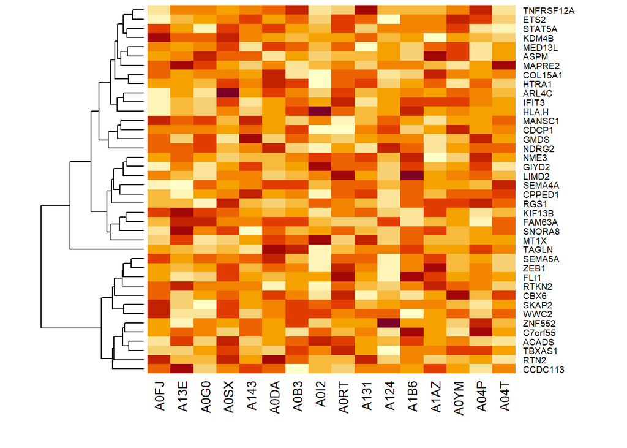

```r
heatmap(data.matrix(dframe[1:40, 1:16]),
        cexRow = 0.7, cexCol = 1,
        Colv = NA)
```

### Annotated Matrix

Gene Ontology used: **None. Annotations loaded from file: data/annotations.csv**

Min. number of genes required to pass the filter: **NA**

Annotated categories: **5**

```r
tar_read(categ_sums)
```

```
##          Neurogenesis       Differentiation Developmental.protein Immunoglobulin.domain            TF.complex
##                    10                    13                    15                    11                     7
```

Features in ROWS: **200**

Samples+Categs in COLUMNS: **155**

(Showing only partial output)

```r
head(tar_read(annot_matrix))
```

```
##             A0FJ     A13E     A0G0     A0SX     A143     A0DA      A0B3     A0I2     A0RT     A131     A124
## RTN2    4.362183 1.984492 1.727323 4.363996 2.447562 4.770798 3.3520618 1.810382 2.094460 4.340912 1.206280
## NDRG2   7.533461 7.455194 8.079968 5.793750 7.158993 8.748061 5.0984040 3.791965 6.327973 4.699950 8.676364
## CCDC113 3.956124 5.427623 2.227300 3.544866 4.691256 4.305401 0.5932056 2.719169 2.357933 3.639056 3.753526
## FAM63A  4.457170 5.440957 5.543480 4.737114 4.808728 5.307480 5.2175851 4.355919 4.041661 4.030187 5.193696
## ACADS   2.256817 4.028813 2.629855 4.269101 2.442135 3.239909 3.8851534 4.200249 4.126817 3.135697 2.789757
## GMDS    6.017940 4.341692 6.363030 4.001104 7.029723 4.236539 5.9178858 4.830286 4.292798 5.251649 5.610192
##             A1B6     A1AZ     A0YM     A04P     A04T     A0AT      A0AL     A0CE     A07R      A0FL     A150
## RTN2    2.846980 1.222353 1.892681 2.293955 1.090914 2.534021 2.4179929 1.763550 3.280434  6.142850 2.308591
## NDRG2   7.790635 4.730645 6.332405 7.827413 7.436516 6.961400 8.8336442 6.544614 6.875960 10.260165 5.887077
## CCDC113 3.060775 4.506151 3.208926 1.881223 3.664815 3.319350 0.2849741 4.309775 2.222412  1.441558 3.790442
## FAM63A  3.819955 4.464141 4.559118 3.709155 5.139812 3.491093 4.6556456 5.179804 5.368074  5.961550 4.274774
## ACADS   4.125045 3.028432 3.393146 2.456713 2.409692 1.834359 4.2644283 3.688115 3.009596  3.850541 3.018863
## GMDS    5.601640 4.144106 4.708556 6.716958 5.173432 5.728591 5.7582700 5.420492 4.877815  6.642912 5.163194
##              A0E0     A0U4     A0XU     A0AV     A0AR     A0RX     A0D2     A0CM     A0WX     A0T0     A0T2
## RTN2    0.6743217 2.218695 3.320557 3.690360 2.910988 2.179577 1.965177 1.903714 3.070428 2.360129 3.620557
## NDRG2   4.5619890 7.385044 7.341238 5.753302 9.515500 7.047445 6.725903 4.983993 6.789360 9.155272 7.013197
## CCDC113 2.2716035 4.860181 4.620859 2.898493 2.883201 3.553867 1.249060 1.779161 4.790587 4.160914 3.172523
## FAM63A  6.0971133 3.800083 4.955763 5.765022 4.940644 4.360755 3.873571 4.664145 4.569566 4.872187 4.834117
## ACADS   4.3603055 3.454774 2.629412 2.778064 4.266805 3.867138 2.698221 1.556919 3.506256 2.350685 4.589873
## GMDS    4.4246369 5.455150 5.699021 4.910252 7.105627 4.995109 5.584181 4.981640 4.736113 4.825226 5.816029
##             A04U     A0JL     A147     A0B9      A1AI     A14X     A12V     A1AY     A0D0     A0SK     A128
## RTN2    1.384660 3.243859 3.505726 2.650759 0.3327526 3.628534 2.813715 3.497809 1.949481 4.794359 1.957013
## NDRG2   8.911393 9.339442 7.000853 7.243034 7.5131668 8.894409 8.556629 5.543856 4.910012 4.484965 3.858092
## CCDC113 1.412959 3.440030 3.978750 3.947715 4.1002872 2.966176 2.243080 4.186226 3.734065 3.500417 4.236216
## FAM63A  3.002935 4.850530 5.789872 4.526164 4.4563209 6.017519 4.719815 5.140818 2.203462 4.008493 1.840127
## ACADS   4.236686 3.006019 2.561543 3.478710 2.1922975 3.740005 3.446792 3.021059 3.308981 3.099769 3.204864
## GMDS    4.715617 5.033427 3.392365 4.530231 5.4230176 6.103145 4.414810 5.021890 4.402124 3.941773 5.958135
##             A04D     A0A7     A094     A12L     A0I9      A0EE     A135     A152     A18P     A18R     A08X
## RTN2    3.264143 3.630609 3.838779 2.836670 4.724076 0.6962941 1.819296 1.986657 3.475001 4.354183 3.733788
## NDRG2   9.645246 5.026081 5.260215 3.344884 4.503244 5.8202163 5.403551 4.999541 4.823776 6.402254 4.675284
## CCDC113 3.930012 2.450502 1.773722 5.404862 4.622169 3.1173445 4.118666 3.577636 4.374714 3.983280 3.294215
## FAM63A  5.762041 3.948055 3.928293 5.957079 5.570075 3.9983956 4.021509 5.645919 5.640225 4.190554 3.351270
## ACADS   3.045266 3.193824 4.305221 3.095219 4.583606 3.0785379 2.832452 2.867549 3.070213 5.606610 3.359589
## GMDS    5.038067 4.443301 5.812546 5.134322 4.819258 6.7714094 3.013772 3.917772 3.582233 2.518043 4.138523
##             A0TX     A09X     A1AT     A12Q     A12T     A0RH     A07I     A04W     A12P     A0EQ      A0D1
## RTN2    2.931286 1.973935 4.178227 2.454749 3.360365 3.105367 3.843009 2.413193 4.780633 2.043937 2.8101153
## NDRG2   6.297263 4.741524 4.883940 4.679603 3.993496 4.467796 3.360024 5.915364 3.728883 4.451327 5.8398955
## CCDC113 4.381832 1.385884 4.041319 5.460908 4.168762 3.280249 5.273710 4.304850 3.611869 3.922623 3.8977020
## FAM63A  4.210461 2.777252 5.143692 7.478075 4.102186 5.490180 6.218413 4.735519 5.428217 3.733726 4.5425832
```

[output cut: 50 more lines]

```
## GMDS    3.129062 4.634938 3.824802 5.385437 4.917877 3.285392 1.983430 2.888763 4.328807 2.646618 5.919961
##             A0H7     A0FS     A0BS     A08O     A12H     A15E     A0W4 Neurogenesis Differentiation
## RTN2    4.286326 4.728350 3.139900 4.346977 3.287485 4.684112 4.294419            0               0
## NDRG2   6.206116 6.857311 6.222359 5.708690 5.043387 6.274357 5.236494            1               1
## CCDC113 3.897574 3.088589 4.306467 3.995944 3.665758 4.599318 4.310629            0               0
## FAM63A  5.390505 6.047637 6.912236 6.189790 5.943128 5.335620 5.955053            0               0
## ACADS   1.802260 5.754979 5.317992 4.488860 4.823124 4.247261 4.631673            0               0
## GMDS    3.603636 3.581223 4.686750 3.186237 5.077987 3.627571 4.648448            0               0
##         Developmental.protein Immunoglobulin.domain TF.complex
## RTN2                        0                     0          0
## NDRG2                       1                     0          0
## CCDC113                     0                     0          0
## FAM63A                      0                     0          0
## ACADS                       0                     0          0
## GMDS                        0                     0          0
```

### Expanded Matrix

Gene Ontology used: **None. Annotations loaded from file: data/annotations.csv**

Min. number of genes applied to filter: **NA**

Annotated categories: **5**

Features+Categs in ROWS: **205**

Samples in COLUMNS: **150**

(Showing only partial output)

```r
tail(tar_read(expd_matrix), ncol(categ_matrix))[,1:10]
```

```
##                           A0FJ     A13E     A0G0     A0SX     A143     A0DA     A0B3     A0I2     A0RT
## Neurogenesis          5.854374 5.556609 5.969148 5.948997 5.877565 6.268727 5.915049 4.614858 6.128434
## Differentiation       6.014111 5.693370 5.697298 5.963823 5.975038 5.968228 5.715979 4.721639 5.928967
## Developmental.protein 5.930771 6.054442 5.965397 6.027754 6.133427 6.201191 5.809003 5.059396 5.897052
## Immunoglobulin.domain 5.178721 4.594623 4.630296 5.565021 4.656773 4.682233 4.948528 4.624139 5.869650
## TF.complex            5.980126 5.808850 5.752035 6.298740 5.617033 5.528551 5.171721 4.449912 6.039300
##                           A131
## Neurogenesis          5.823166
## Differentiation       6.038837
## Developmental.protein 6.024545
## Immunoglobulin.domain 5.379455
## TF.complex            5.014576
```

### Heatmap (after row expansion)

Features+Categs in ROWS; Samples in COLUMNS

(Showing full and partial output)

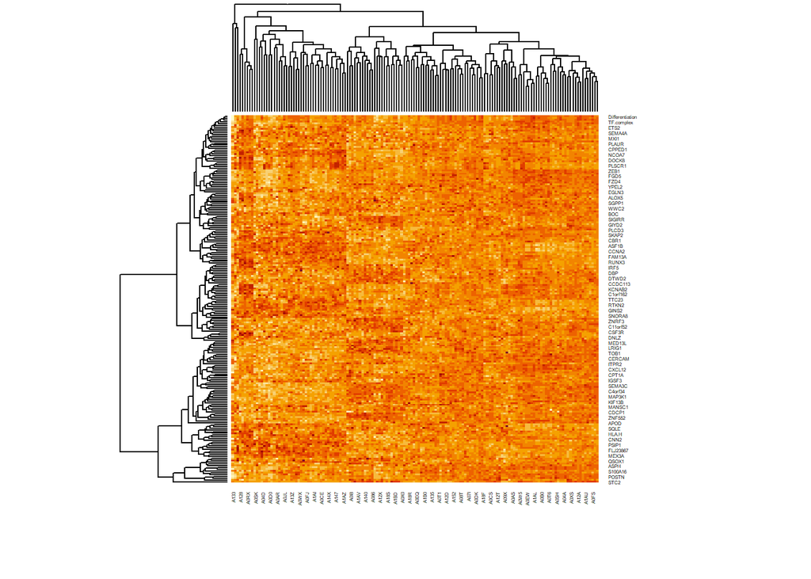

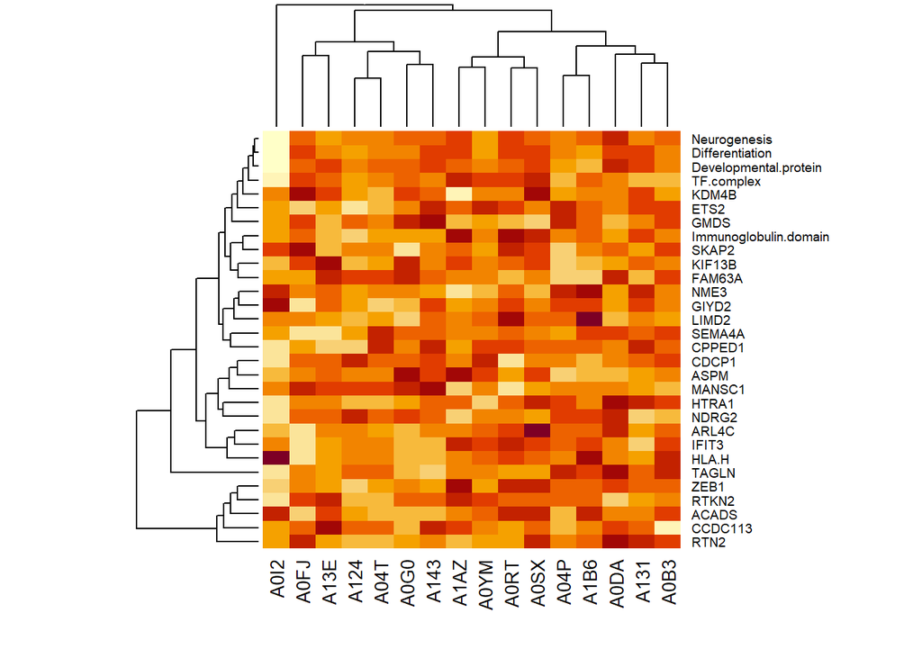